# CEE218X_R2

Jordan Brinn

10/27/2020

Educational attainment analysis for Alameda County

```r
acs_vars_2018_5yr <-
  listCensusMetadata(
    name = "2018/acs/acs5",
    type = "variables"
  )
saveRDS(acs_vars_2018_5yr,"acs_vars_2018_5yr.rds")
```

```r
acs_vars_2018_5yr <- readRDS("acs_vars_2018_5yr.rds")
```

```r
bay_county_names <-
  c(
    "Alameda",
    "Contra Costa",
    "Marin",
    "Napa",
    "San Francisco",
    "San Mateo",
    "Santa Clara",
    "Solano",
    "Sonoma"
  )
bay_counties <-
  counties("CA", cb = T, progress_bar = F) %>%
  filter(NAME %in% bay_county_names)
```

Part 1 - Educational Attainment (population 25+ years old) and School Enrollment by Race

Generally, White and Asian populations make up a higher proportion of the total populations who are currently enrolled in or have graduated from higher education programs than would be expected based on the proportion of the total population of the county that they represent. Therefore, Native, Black, and other or mixed race populations tend to be underrepresented at the higher levels than would be expected from the total. Racial proportions vary some between preschool and grades K-12, but there does not appear to be any significant trend of variation from what would be expected based on total population proportions. The disparities remain at the higher levels of educational attainment.

```r
#loading and cleaning school enrollment by race census data
census_race_labels <-
  c(
    "White Alone",
    "Black or African American",
    "American Indian and Alaska Native Alone",
    "Asian Alone",
    "Native Hawaiian and Other Pacific Islander Alone)",
    "Some Other Race Alone",
    "Two or More Races"
  )

A_school_enrollment_race <-
  1:7 %>%
  map_dfr(function(x){
    getCensus(
      name = "acs/acs5",
      vintage = 2018,
      region = "county:001",
      regionin = "state:06",
      vars = paste0("group(B14007",LETTERS[x],")")
    ) %>%
      select(!c(GEO_ID,state,NAME) & !ends_with(c("EA","MA","M"))) %>%
      pivot_longer(
        ends_with("E"),
        names_to = "variable",
        values_to = "estimate"
      ) %>%
      left_join(
        acs_vars_2018_5yr %>%
          select(name, label),
        by = c("variable" = "name")
      ) %>%
      select(-variable) %>%
      separate(
        label,
        into = c(NA,NA,NA,"enrollment"),
        sep = "!!"
      ) %>%
      filter(!is.na(enrollment)) %>%
      mutate(race = census_race_labels[x])
  })
```

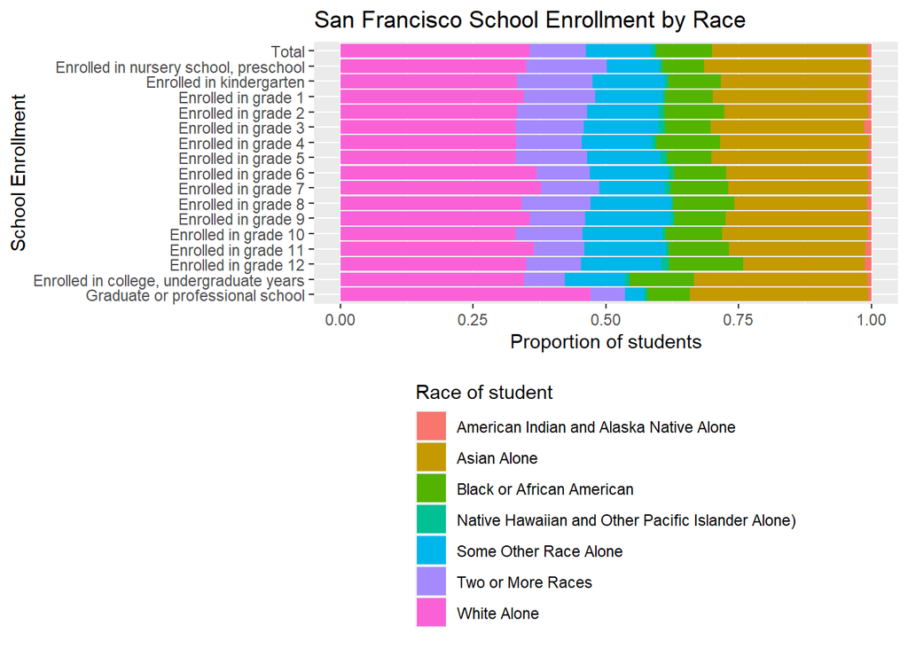

```r
#horizontal bar chart of proportions of different races of students in Alameda County separated by grade
A_school_enrollment_total <-
  A_school_enrollment_race %>%
  group_by(race) %>%
  summarize(estimate = sum(estimate)) %>%
  mutate(enrollment = "Total")

A_school_enrollment_race %>%
  group_by(enrollment, race) %>%
  summarize(estimate = sum(estimate)) %>%
  rbind(A_school_enrollment_total) %>%
  ggplot() +
  geom_bar(
    aes(
      x = enrollment %>% factor(levels = rev(c("Total",A_school_enrollment_race$enrollment[1:16]))),
      y = estimate,
      fill = race
    ),
    stat = "identity",
    position = "fill"
  ) +
  labs(
    x = "School Enrollment",
    y = "Proportion of students",
    title = "San Francisco School Enrollment by Race",
    fill = "Race of student"
  ) +
  coord_flip() +
  theme(
    legend.position = "bottom",
    legend.direction = "vertical"
  )
```

Horizontal bar chart of proportions of different races of students in Alameda County separated by grade White and Asian populations are overrepresented in graduate and professional school compared to their total population percentages while Black, Native, and Mixed Race populations are underrepresented at that level. At the college level, Asian populations are overrepresented compared to their total while Two or More Races and Some Other Race are underrepresented. There are slight variations throughout different grade levels, but the race population proportions overall for k-12 hover around their total proportions.

```r
#loading and cleaning educational attainment by race census data (table also includes sex data)
A_educ_attain_race <-
  1:7 %>%
  map_dfr(function(x){
    getCensus(
      name = "acs/acs5",
      vintage = 2018,
      region = "county:001",
      regionin = "state:06",
      vars = paste0("group(C15002",LETTERS[x],")")
    ) %>%
      select(!c(GEO_ID,state,NAME) & !ends_with(c("EA","MA","M"))) %>%
      pivot_longer(
        ends_with("E"),
        names_to = "variable",
        values_to = "estimate"
      ) %>%
      left_join(
        acs_vars_2018_5yr %>%
          select(name, label),
        by = c("variable" = "name")
      ) %>%
      select(-variable) %>%
      separate(
        label,
        into = c(NA,NA,"sex","attainment"),
        sep = "!!"
      ) %>%
      filter(!is.na(attainment)) %>%
      filter(!is.na(sex)) %>%
      mutate(race = census_race_labels[x])
  })
```

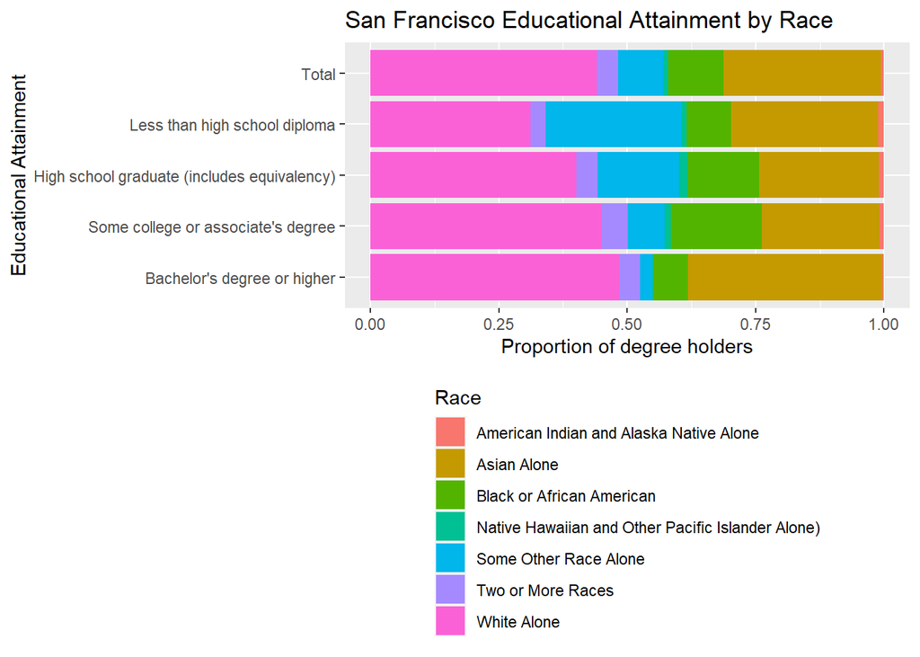

```r
#horizontal bar chart of racial proportion breakdown by educational attainment in Alameda County
A_educ_attain_total <-
  A_educ_attain_race %>%
  group_by(race) %>%
  summarize(estimate = sum(estimate)) %>%
  mutate(attainment = "Total")

A_educ_attain_race %>%
  group_by(attainment, race) %>%
  summarize(estimate = sum(estimate)) %>%
  rbind(A_educ_attain_total) %>%
  ggplot() +
  geom_bar(
    aes(
      x = attainment %>% factor(levels = rev(c("Total",A_educ_attain_race$attainment[1:4]))),
      y = estimate,
      fill = race
    ),
    stat = "identity",
    position = "fill"
  ) +
  labs(
    x = "Educational Attainment",
    y = "Proportion of degree holders",
    title = "San Francisco Educational Attainment by Race",
    fill = "Race"
  ) +
  coord_flip() +
  theme(
    legend.position = "bottom",
    legend.direction = "vertical"
  )
```

Horizontal bar chart of racial proportion breakdown by educational attainment in Alameda County Asian and White populations are overrepresented in the Bachelor’s degree or higher category while all other racial categories are underrepresented compared to their representation in the total population. The opposite is true in both the less than a high school diploma and the high school graduate/equivalent categories. Finally, in the some college or associate’s degree category, Asian population is underrepresented, Black population is overrepresented, and all other populations make up a proportion that is approximately equivalent to their total.

Part 2 - Estimate of % K-12 students in PUMAs within the Bay Area and Alameda County specifically that have no internet access at home based on 2019 PUMs data

All PUMAs, with the exception of 1, are in the 0 - 6% range for K-12 students without internet access. The remaining PUMA (#104) lies within Alameda County, and 20% of K-12 students there do not have internet access. There does not to seem to be any immediate indicators of recording errors within the PUMs data that caused the outlier (e.g. all PWGTP weights are within a typical range). Looking at maps of income and race in the Bay Area (sources below), the area seems to have a higher proportion of low income, specifically low income minority, populations compared to the rest of the Bay Area, so this lack of internet access likely indicates a major equity concern especially now that the current pandemic has required much of the educational experience to be moved to an online format. Today, lack of internet access for K-12 students is essentially equivalent to lack of access to education, and local governments and non-profits should focus on methods for reducing this gap quickly otherwise the education gap for students without internet will continue to rapidly grow.

Sources:

https://www.smithsonianmag.com/innovation/these-maps-help-explain-numerous-complicated-factors-behind-income-inequality-180955941/

https://www.opportunityatlas.org/ –> filtered for % Non-White and Median Household Income

```r
#2019 PUMs data for grade level and internet access
census_api_key("0b9dfaf3fa0df7bb9bce2b33001ae985230cc118")
ca_pums2019 <- get_pums(
  variables = c(
    "PUMA",
    "ACCESS",
    "SCHG",
    "AGEP"
  ),
  state = "CA",
  year = 2019,
  survey = "acs1",
  recode = T
)
saveRDS(ca_pums2019,"ca_pums2019.rds")
```

```r
#filter PUMAs and PUMs for Bay Area
ca_pumas2019 <-
  pumas("CA", cb = T, progress_bar = F)

bay_pumas2019 <-
  ca_pumas2019 %>%
  st_centroid() %>%
  .[bay_counties, ] %>%
  st_set_geometry(NULL) %>%
  left_join(ca_pumas2019 %>% select(GEOID10)) %>%
  st_as_sf()

bay_pums2019 <-
  ca_pums2019 %>%
  filter(PUMA %in% bay_pumas2019$PUMACE10)
```

```r
#filter PUMAs and PUMs for Alameda County
alameda_county <-
  bay_counties %>%
  filter(NAME == "Alameda")

alameda_pumas <-
  bay_pumas2019 %>%
  st_centroid() %>%
  .[alameda_county, ] %>%
  st_set_geometry(NULL) %>%
  left_join(bay_pumas2019 %>% select(GEOID10)) %>%
  st_as_sf()

alameda_pums <-
  bay_pums2019 %>%
  filter(PUMA %in% alameda_pumas$PUMACE10)
```

```r
#count total students (using personal weights) in K-12 and those who do not have internet access in their home --> use to calculate percent of K-12 students in each PUMA without home internet access
alameda_internet_access <-
  alameda_pums %>%
  mutate(SCHG = as.numeric(SCHG)) %>%
  mutate(
    student_no_internet = ifelse(
      (ACCESS == "3") &
        (SCHG %in% 2:14),
      PWGTP,
      0
    )
  ) %>%
  mutate(
    total_k12_students = ifelse(
      (SCHG %in% 2:14),
      PWGTP,
      0
    )
  ) %>%
  mutate(PUMA = as.numeric(PUMA)) %>%
  group_by(PUMA) %>%
  summarize(
    perc_student_no_internet =
      sum(student_no_internet, na.rm =T)/sum(total_k12_students, na.rm = T)*100
  ) %>%

  left_join(
    alameda_pumas %>%
      transmute(
        PUMA = as.numeric(PUMACE10)
        )
     ) %>%
  st_as_sf()

pums_pal <- colorNumeric(
  palette = "Oranges",
  domain = alameda_internet_access$perc_student_no_internet
)

leaflet() %>%
  addTiles() %>%
  addProviderTiles("Esri.WorldGrayCanvas") %>%
  addPolygons(
    data = alameda_internet_access,
    fillColor = ~pums_pal(perc_student_no_internet),
    color = "white",
    opacity = 0.5,
    fillOpacity = 0.5,
    weight = 1,
    label = ~paste0(
      round(perc_student_no_internet),
      "% K-12 Students with No Access to the Internet in their Home"
    ),
    highlightOptions = highlightOptions(
      weight = 2,
      opacity = 1
    )
  ) %>%
  addLegend(
    data = alameda_internet_access,
    pal = pums_pal,
    values = ~perc_student_no_internet ,
    title = "% K-12 Students with<br>No Access to the<br>Internet in their Home"
  )
```

[interactive chart not shown]

Map of % of K-12 students in each PUMA within Alameda County who do not have access to the internet at home

```r
bay_internet_access <-
  bay_pums2019 %>%
  mutate(SCHG = as.numeric(SCHG)) %>%
  mutate(
    student_no_internet = ifelse(
      (ACCESS == "3") &
        (SCHG %in% 2:14),
      PWGTP,
      0
    )
  ) %>%
  mutate(
    total_k12_students = ifelse(
      (SCHG %in% 2:14),
      PWGTP,
      0
    )
  ) %>%
  mutate(PUMA = as.numeric(PUMA)) %>%
  group_by(PUMA) %>%
  summarize(
    perc_student_no_internet =
      sum(student_no_internet, na.rm =T)/sum(total_k12_students, na.rm = T)*100
  ) %>%

  left_join(
    bay_pumas2019 %>%
      transmute(
        PUMA = as.numeric(PUMACE10)
        )
     ) %>%
  st_as_sf()

pums_pal <- colorNumeric(
  palette = "Oranges",
  domain = bay_internet_access$perc_student_no_internet
)

leaflet() %>%
  addTiles() %>%
  addProviderTiles("Esri.WorldGrayCanvas") %>%
  addPolygons(
    data = bay_internet_access,
    fillColor = ~pums_pal(perc_student_no_internet),
    color = "white",
    opacity = 0.5,
    fillOpacity = 0.5,
    weight = 1,
    label = ~paste0(
      round(perc_student_no_internet),
      "% K-12 Students with No Access to the Internet in their Home"
    ),
    highlightOptions = highlightOptions(
      weight = 2,
      opacity = 1
    )
  ) %>%
  addLegend(
    data = bay_internet_access,
    pal = pums_pal,
    values = ~perc_student_no_internet ,
    title = "% K-12 Students with<br>No Access to the<br>Internet in their Home"
  )
```

[interactive chart not shown]

Map of % of K-12 students in each PUMA within the Bay Area who do not have access to the internet at home

Part 3 - A migration analysis of eduacational attainment in Alameda County between 2018 and 2019 based on census data

```r
acs_vars_2019_1yr <-
  listCensusMetadata(
    name = "2019/acs/acs1",
    type = "variables"
  )
```

```r
#B07009 = Geographic Mobility in the past year by education attainment
A_mobility_current_19 <-
  getCensus(
    name = "acs/acs1",
    vintage = 2019,
    region = "county:001",
    regionin = "state:06",
    vars = c("group(B07009)")
  ) %>%
  select(!c(GEO_ID,state,NAME) & !ends_with(c("EA","MA","M"))) %>%
  pivot_longer(
    ends_with("E"),
    names_to = "variable",
    values_to = "estimate"
  ) %>%
  left_join(
    acs_vars_2019_1yr %>%
      select(name, label),
    by = c("variable" = "name")
  ) %>%
  select(-variable) %>%
  separate(
    label,
    into = c(NA,NA,"mobility","educ"),
    sep = "!!"
  ) %>%
  mutate(
    mobility = ifelse(
      mobility %in% c("Same house 1 year ago:", "Moved within same county:"),
      "Here since last year",
      "Inflow"
    )
  ) %>%
  filter(!is.na(educ)) %>%
  group_by(mobility, educ) %>%
  summarize(estimate = sum(estimate))
```

```r
#B07409 Geographic Mobility in the past year by educ attainment 1 year ago
A_mobility_lastyear_19 <-
  getCensus(
    name = "acs/acs1",
    vintage = 2019,
    region = "county:001",
    regionin = "state:06",
    vars = c("group(B07409)")
  ) %>%
  select(!c(GEO_ID,state,NAME) & !ends_with(c("EA","MA","M"))) %>%
  pivot_longer(
    ends_with("E"),
    names_to = "variable",
    values_to = "estimate"
  ) %>%
  left_join(
    acs_vars_2019_1yr %>%
      select(name, label),
    by = c("variable" = "name")
  ) %>%
  select(-variable) %>%
  separate(
    label,
    into = c(NA,NA,"mobility","educ"),
    sep = "!!"
  ) %>%
  mutate(
    mobility = ifelse(
      mobility %in% c("Same house:", "Moved within same county:"),
      "Here since last year",
      "Outflow"
    ),
  ) %>%
  filter(!is.na(educ)) %>%
  group_by(mobility, educ) %>%
  summarize(estimate = sum(estimate))
```

```r
A_mobility_current_18 <-
  getCensus(
    name = "acs/acs1",
    vintage = 2018,
    region = "county:001",
    regionin = "state:06",
    vars = c("group(B07009)")
  ) %>%
  select(!c(GEO_ID,state,NAME) & !ends_with(c("EA","MA","M"))) %>%
  pivot_longer(
    ends_with("E"),
    names_to = "variable",
    values_to = "estimate"
  ) %>%
  left_join(
    acs_vars_2019_1yr %>%
      select(name, label),
    by = c("variable" = "name")
  ) %>%
  select(-variable) %>%
  separate(
    label,
    into = c(NA,NA,"mobility","educ"),
    sep = "!!"
  ) %>%
  mutate(
    mobility = "Here last year"
  ) %>%
  filter(!is.na(educ)) %>%
  group_by(mobility, educ) %>%
  summarize(estimate = sum(estimate))
```

```r
A_flows_19 <-
  rbind(
    A_mobility_current_18,
    A_mobility_lastyear_19 %>%
      filter(mobility == "Outflow"),
    A_mobility_current_19 %>%
      filter(mobility == "Inflow"),
    A_mobility_current_19 %>%
      group_by(educ) %>%
      summarize(estimate = sum(estimate)) %>%
      mutate(mobility = "Here this year")
  ) %>%
  pivot_wider(
    names_from = mobility,
    values_from = estimate
  ) %>%
  mutate(
    `External net` = Inflow - Outflow,
    `Internal net` = `Here this year` - `Here last year` - `External net`,
  ) %>%
  select(
    `Educational Attainment` = educ,
    `Internal net`,
    `External net`,
    `Here last year`,
    `Here this year`,
    Outflow,
    Inflow
  )

A_flows_19
```

```
## # A tibble: 5 x 7
##   `Educational At~ `Internal net` `External net` `Here last year`
##   <chr>                     <dbl>          <dbl>            <dbl>
## 1 Bachelor's degr~          18271           6034           326386
## 2 Graduate or pro~           6148           1515           246460
## 3 High school gra~          -7992            -15           214368
## 4 Less than high ~          -1335           1174           124223
## 5 Some college or~          -8890          -6028           274788
## # ... with 3 more variables: `Here this year` <dbl>, Outflow <dbl>,
## #   Inflow <dbl>
```